# DATA607 Final

Gabriella Martinez, Maliat Hossain, Gabriel Campos

May 11 2021

# Assignment

## Requirements

$MSDA\ 607\ Final\ Project$

Deliverables Schedule

| *Deliverable* | *Date* | *Points* |
| --- | --- | --- |
| One Paragraph Proposal | Sunday April 26 | 20 |
| Final Project | Sunday May 10 | 120 |
| Final Project Presentation | Before or during Final Meetup on Wednesday May 13 | 30 |

Policy on Collaboration

You may work in a team of up to three people. Each project team member is responsible for understanding and being able to explain all of the submitted project code. Remember that you can take work that you find elsewhere as a base to build on, but you need to acknowledge the source, so that I base your grade on what you contributed, not on what you started with!

Approval Meeting

Once you’ve turned in your one paragraph proposal, I want to schedule a 15 minute phone meeting with each person or team (starting when we return from Thanksgiving break), where you’ll describe the reason (benefit) for doing this work and/or question you’re seeking to answer, where you’ll source the data, and the overall flow. For team projects, I also want you to articulate the roles and responsibilities of each team member.

Final Project Checklist

To receive full credit, you’ll need to deliver on all of the items in the checklist below. Please read carefully through this checklist before you make your project proposal. You are (within these checklist constraints) strongly urged to limit scope and make the necessary simplifying assumptions so that you can deliver your work on time!

- Proposal describes your motivation for performing this analysis
- Proposal describes likely data sources.
- Your project has a recognizable “data science workflow,” such as the OSEMN workflow or Hadley Wickham’s Grammar of Data Science. [Example: First the data is acquired, then necessary transformations and clean-up are performed, then the analysis and presentation work is performed]
- Project includes data from at least two different types of data sources (e.g., two or more of these: relational or CSV,Neo4J, web page [scraped or API], MongoDB, etc.)
- Project includes at least one data transformation operation. [Examples: transforming from wide to long; converting columns to date format]
- Project includes at least one statistical analysis and at least one graphics that describes or validates your data.
- Project includes at least one graphic that supports your conclusion(s).
- Project includes at least one statistical analysis that supports your conclusion(s).
- Project includes at least one feature that we did not cover in class! There are many examples: “I used ggmap; I created a decision tree; I ranked the results; I created my presentation slides directly from R; I figured out to use OAuth 2.0…”
- Presentation. Was the presentation delivered in the allotted time (3 to 5 minutes)?
- Presentation. Did you show (at least) one challenge you encountered in code and/or data, and what you did when you encountered that challenge? If you didn’t encounter any challenges, your assignment was clearly too easy for you!
- Presentation. Did the audience come away with a clear understanding of your motivation for undertaking the project?
- Presentation. Did the audience come away with a clear understanding of at least one insight you gained or conclusion you reached or hypothesis you “confirmed” (rejected or failed to reject…)?
- Code and data. Have you delivered the submitted code and data where it is self-contained—preferably in rpubs.com and github? Am I able to fully reproduce your results with what you’ve delivered? You won’t receive full credit if your code references data on your local machine!
- Code and data. Does all of the delivered code run without errors?
- Code and data. Have you delivered your code and conclusions using a “reproducible research” tool such as RMarkdown?
- Deadline management. Were your draft project proposal, project, and presentation delivered on time? Any part of the project that is turned in late will receive a maximum grade of 80%. Please turn in your work on time! You are of course welcome to deliver ahead of schedule!

## Scope

[figure not shown]

## Data Preparation

### Load Data

In order to conduct our studies we used data from [U.S. Bureau of Labor Statistics](https://www.bls.gov/cps/tables.htm#empstat) specifically data regarding:

```r
url_9  <- "https://www.bls.gov/web/empsit/cpseea09.htm"
url_10 <- "https://www.bls.gov/web/empsit/cpseea10.htm"
url_34 <- "https://www.bls.gov/cps/cpsaat34.htm"
url_34_xsls <- "https://www.bls.gov/cps/cpsaat34.xlsx"
```

```r
head(df_tb9  <- as.data.frame(html_table(read_html(url_9))[[2]]),5)
```

```
##   Age, sex, and marital status   2020   2020   2020   2020   2020   2020   2020
## 1 Age, sex, and marital status   Apr.    May   June   July   Aug.  Sept.   Oct.
## 2                  AGE AND SEX
## 3     Total, 16 years and over 23,109 20,975 17,697 16,308 13,542 12,535 11,049
## 4               16 to 19 years  1,636  1,653  1,222  1,024    924    963    836
## 5               16 to 17 years    504    582    452    363    314    371    299
##     2020   2020   2021  2021  2021  2021
## 1   Nov.   Dec.   Jan.  Feb.  Mar.  Apr.
## 2
## 3 10,728 10,736 10,130 9,972 9,710 9,812
## 4    825    946    865   825   771   754
## 5    314    302    337   325   278   261
```

```r
head(df_tb10 <- as.data.frame(html_table(read_html(url_10))[[2]]),5)
```

```
##   Age, sex, and marital status 2020 2020 2020 2020 2020  2020 2020 2020 2020
## 1 Age, sex, and marital status Apr.  May June July Aug. Sept. Oct. Nov. Dec.
## 2                  AGE AND SEX
## 3     Total, 16 years and over 14.8 13.3 11.1 10.2  8.4   7.8  6.9  6.7  6.7
## 4               16 to 19 years 32.1 29.6 22.6 19.1 16.4  16.3 14.0 13.9 16.0
## 5               16 to 17 years 28.0 29.0 23.2 17.7 14.8  17.2 14.1 14.9 14.5
##   2021 2021 2021 2021
## 1 Jan. Feb. Mar. Apr.
## 2
## 3  6.3  6.2  6.0  6.1
## 4 14.8 13.9 13.0 12.3
## 5 15.9 14.8 12.6 11.3
```

```r
head(df_tb34 <- as.data.frame(html_table(read_html(url_34))[[2]]),5)
```

```
##                                           Sex and reason       2020        2020
## 1                                         Sex and reason Unemployed  Unemployed
## 2                                         Sex and reason      Total Job-seekers
## 3                                       Total unemployed     12,947       6,577
## 4 Job losers and persons who completed temporary jobs(1)      9,770       3,399
## 5                                            Job leavers        683         683
##                                 2020                                    2020
## 1 Percent of jobseekers using method      Percent of jobseekers using method
## 2          Contactedemployerdirectly Sent outresumesor filledoutapplications
## 3                               49.1                                    56.0
## 4                               49.6                                    56.8
## 5                               51.5                                    58.7
##                                 2020                               2020
## 1 Percent of jobseekers using method Percent of jobseekers using method
## 2                Placedoransweredads        Contactedfriendsorrelatives
## 3                               14.2                               24.5
## 4                               16.0                               27.8
## 5                               14.3                               22.2
##                                 2020                               2020
## 1 Percent of jobseekers using method Percent of jobseekers using method
## 2            Publicemploy-mentagency           Privateemploy-mentagency
## 3                               14.3                                8.3
## 4                               17.0                               10.2
## 5                               12.2                                7.1
##                                 2020                        2020
## 1 Percent of jobseekers using method Averagenumber ofmethodsused
## 2                              Other Averagenumber ofmethodsused
## 3                               15.2                         1.8
## 4                               15.8                         1.9
## 5                               14.1                         1.8
```

### Transform Data

```r
colnames(df_tb10) <- cbind(c("Label","2020-03", "2020-04",
                         "2020-05", "2020-06", "2020-07",
                         "2020-08", "2020-09", "2020-10",
                         "2020-11", "2020-12","2021-01",
                         "2021-02", "2021-03"))


colnames(df_tb9) <- c("Label", "2020-03", "2020-04",
                         "2020-05", "2020-06", "2020-07",
                         "2020-08", "2020-09", "2020-10",
                         "2020-11", "2020-12","2021-01",
                         "2021-02", "2021-03")
```

```r
df_tb9_tdy<-
    as.data.frame(df_tb9[1,]%>%
      assign_in(list(1,1),"Month")%>%
        bind_rows(
          df_tb9[3,],
          (df_tb9[4:14,]%>%
                      select(1)%>%
                        #lapply(function(x){ gsub("^", "Total, ", x)})%>%
                              cbind(df_tb9[4:14,2:14])),
          df_tb9[16,],
          (df_tb9[17:27,]%>%
                      select(1)%>%
                        #lapply(function(x){gsub("^", "Men, ", x)})%>%
                              cbind(df_tb9[17:27,2:14])),
          df_tb9[29,],
          (df_tb9[30:40,]%>%
                      select(1)%>%
                        #lapply(function(x){gsub("^", "Women, ", x)})%>%
                              cbind(df_tb9[30:40,2:14]))
                  )
    )
# # Adding male and female category
# df_tb9_tdy$Gender <- ifelse(grepl("Men,", df_tb9_tdy$Label), "Male",
#                             ifelse(grepl("Women,", df_tb9_tdy$Label), "Female", ""))

df_tb9_tdy$Gender <- "Total"
df_tb9_tdy$Gender[14:25] <- "Male"
df_tb9_tdy$Gender[26:37] <- "Female"
```

And repeated for `Table 10`

```r
df_tb10_tdy<-
    as.data.frame(df_tb10[1,]%>%
    assign_in(list(1,1),"Month")%>%
        bind_rows(df_tb10[3,],(df_tb10[4:14,]%>%
                      select(1)%>%
                      #lapply(function(x){gsub("^", "Total, ", x)})%>%
                              cbind(df_tb10[4:14,2:14])),
          df_tb10[16,],
          (df_tb10[17:27,]%>%
                      select(1)%>%
                        #lapply(function(x){gsub("^", "Men, ", x)})%>%
                              cbind(df_tb10[17:27,2:14])),
          df_tb10[29,],
          (df_tb10[30:40,]%>%
                      select(1)%>%
                        #lapply(function(x){gsub("^", "Women, ", x)})%>%
                              cbind(df_tb10[30:40,2:14]))))
# Adding male and female category
# df_tb10_tdy$Gender <- ifelse(grepl("Men,", df_tb10_tdy$Label), "Male",
#                             ifelse(grepl("Women,", df_tb10_tdy$Label), "Female", ""))

df_tb10_tdy$Gender <- "Total"
df_tb10_tdy$Gender[14:25] <- "Male"
df_tb10_tdy$Gender[26:37] <- "Female"
```

Transposed for `df_tdy_tb9` and repeated for `df_tdy_tb10`.

```r
df_tb9_tdy_t <-
  df_tb9_tdy%>%
    rownames_to_column() %>%
      pivot_longer(-rowname, 'variable', 'value') %>%
        pivot_wider(variable, rowname)%>%
          janitor::row_to_names(1)
df_tb10_tdy_t <-
  df_tb10_tdy%>%
    rownames_to_column() %>%
      pivot_longer(-rowname, 'variable', 'value') %>%
        pivot_wider(variable, rowname)%>%
          janitor::row_to_names(1)
```

Sorted by categories

```r
# df_tb9_tdy_ts <-
#   df_tb9_tdy_t %>%
#   select(1,2,3,15,4,16,5,17,6,18,7,19,8,20,9,21,10,22,11,23,12,24,13,25,14,26)
```

```r
test<- df_tb10_tdy[,1:14]%>%
          rbind(df_tb10_tdy[c(14,26),1:14]) %>%
          gather("Month_Year", "Rate", 2:14)
```

[^1]

[figure not shown]

```r
# Month over Month employment rate change by gender
#Dependency on df_tb9_tdy:     Rate and Gender
t_9 <- df_tb9_tdy %>%
  slice(c(14,26)) %>%
  gather("Month_Year", "Count", 2:14)

t_9$Month_Year<- as.yearmon(t_9$Month_Year)
t_9$Count <- as.numeric(gsub(",","",t_9$Count))
#glimpse(t_9)

t_9 <- t_9 %>%
  group_by(Gender) %>%
  mutate(MoM = (Count - lag(Count)) / lag(Count)) %>%
  mutate(MoM_Rate =  round(MoM * 100, 1))


##bar plot month over month gender
ggplot(t_9, aes(x=factor(Month_Year), y=MoM, fill=Gender)) +
  geom_col(position="dodge") +
  scale_y_continuous(labels = scales::percent)+
  theme_minimal()+
  theme(axis.text.x = element_text(angle = 45, hjust=1))+
  labs(title = 'Month over Month Employment Rate Change by Gender'
       ,subtitle = "03/2020-03/2021",
       x = "Month", y = "Rate Chnage")
```

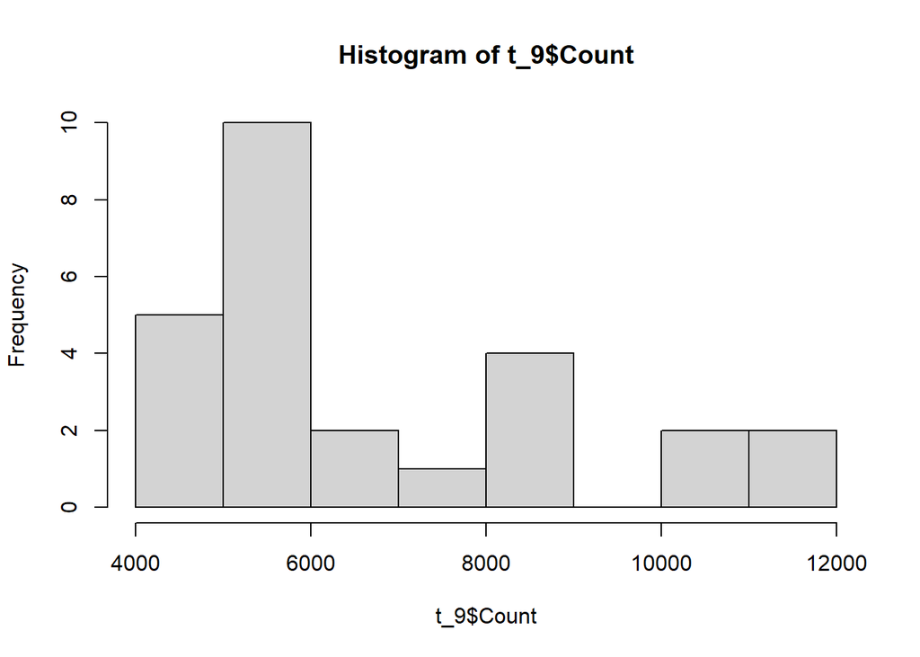

```r
#testing linear model. issue: gender is categorical var- need to look into this
# only accounts for 1.18% of data, Multiple R-squared:  0.0118
hist(t_9$Count)
```

```r
tst_lm <- lm(Count~Gender, t_9)
tst_lm
```

```
##
## Call:
## lm(formula = Count ~ Gender, data = t_9)
##
## Coefficients:
## (Intercept)   GenderMale
##      6540.8        480.2
```

```r
summary(tst_lm)
```

```
##
## Call:
## lm(formula = Count ~ Gender, data = t_9)
##
## Residuals:
##    Min     1Q Median     3Q    Max
##  -2123  -1627  -1095   1431   5293
##
## Coefficients:
##             Estimate Std. Error t value Pr(>|t|)
## (Intercept)   6540.8      634.3  10.312 2.69e-10 ***
## GenderMale     480.2      897.1   0.535    0.597
## ---
## Signif. codes:  0 '***' 0.001 '**' 0.01 '*' 0.05 '.' 0.1 ' ' 1
##
## Residual standard error: 2287 on 24 degrees of freedom
## Multiple R-squared:  0.0118, Adjusted R-squared:  -0.02938
## F-statistic: 0.2865 on 1 and 24 DF,  p-value: 0.5974
```

[figure not shown]

```r
# Month over Month employment rate change by age and gender
#Dependency on df_tb9_tdy:     Count, age, and Gender
library(stats)
tbl_9 <- df_tb9_tdy %>%
  slice(c(16,17,19,22,23,24,25,28,29,31,34,35,36,37)) %>%
  gather("Month_Year", "Count", 2:14)

tbl_9$Month_Year<- as.yearmon(tbl_9$Month_Year)
tbl_9$Count <- as.numeric(gsub(",","",tbl_9$Count))
#glimpse(tbl_9)

tbl_9 <- tbl_9 %>%
  group_by(Gender, Label) %>%
  mutate(MoM = (Count - lag(Count)) / lag(Count)) %>%
  mutate(MoM_Rate =  round(MoM * 100, 1))


##bar plot month over month age grp and geneder
(ggplot(tbl_9, aes(x=factor(Month_Year), y = (MoM), color = Gender, group = Gender, fill=Gender)) +
  geom_col(position="dodge") +
  theme_minimal()+
  theme(axis.text.x = element_text(angle=45, hjust=1))+
  labs(title= 'Month over Month Employment Rate Change by Gender',
       subtitle="03/2020-03/2021",
       x="Month", y="Rate Change")+
  facet_wrap( ~ Label, scales = "free_y"))
```

#######tables for the line graphs######

```r
#Dependency on df_tb10_tdy:     Rate and Gender
#data transformation operation: from wide to long function: gather, package: tidyr
test3 <- df_tb10_tdy %>%
  slice(c(14,26)) %>%
  gather("Month_Year", "Rate", 2:14)

#data transformation operation: date format function: as.yearmon, package: zoo
test3$Month_Year<- as.yearmon(test3$Month_Year)
test3$Rate <- as.numeric(test3$Rate)
```

```r
#Dependency on df_tb10_tdy    Rate, Gender, Age Group
test2 <- df_tb10_tdy %>%
  slice(c(16,17,19,22,23,24,25,28,29,31,34,35,36,37)) %>%
  gather("Month_Year", "Rate", 2:14)

test2$Month_Year<- as.yearmon(test2$Month_Year)
test2$Rate <- as.numeric(test2$Rate)
```

## Visualizations

[figure not shown]

```r
#line graph Unemployment Rates by Gender
ggplot(test3, aes(x=factor(Month_Year), y = (Rate), color = Gender, group = Gender)) +
  geom_line() +
  geom_point(size = 4, shape = 21) + # Also use a point with a color fill
  scale_y_continuous(limits = c(4, 16.5))+
  theme_minimal()+
  theme(axis.text.x = element_text(angle = 45, hjust=1))+
  labs(title = 'Unemployment Rates by Gender'
       ,subtitle = "03/2020-03/2021",
       x = "Month", y = "Rate")
```

[figure not shown]

```r
#barplot Unemployment Rates by Gender
ggplot(test3, aes(x=factor(Month_Year), y = (Rate), color = Gender, group = Gender, fill=Gender)) +
  geom_col(position="dodge") +
  theme_minimal()+
  theme(axis.text.x = element_text(angle = 45, hjust=1))+
  labs(title = 'Unemployment Rates by Gender'
       ,subtitle = "03/2020-03/2021",
       x = "Month", y = "Rate")
```

```r
# #staked bar plot
# p4 <- ggplot() +
#   geom_bar(aes(y = Rate, x = factor(Month_Year),
#     fill = Gender), data = test3,
#     stat="identity")+theme_minimal()+
#   theme(axis.text.x = element_text(angle = 45, hjust=1))+
#   labs(title = 'Unemployment Rates by Gender'
#        ,subtitle = "03/2020-03/2021",
#        x = "Month", y = "Rate")
# p4
```

[^2]

[figure not shown]

```r
#Unemployment Rates by Age Group *&* Gender line
(ggplot(data=test2, aes(Month_Year, Rate, color=Gender, group=Gender)) +
  geom_line(size = 1) +
  geom_point() +
  theme_minimal()+
  theme(axis.text.x = element_text(angle=45, hjust=1))+
  labs(title= 'Unemployment Rates by Age Group and Gender',
       subtitle="03/2020-03/2021",
       x="Month", y="Rate")+
  facet_wrap( ~ Label, scales = "free_y"))
```

[figure not shown]

```r
#Unemployment Rates by Age Group *&* Gender bar
(ggplot(data=test2, aes(x=factor(Month_Year), y = (Rate), color = Gender, group = Gender, fill=Gender)) +
  geom_col(position="dodge") +
  theme_minimal()+
  theme(axis.text.x = element_text(angle=90, hjust=1))+
  labs(title= 'Unemployment Rates by Age Group and Gender',
       subtitle="03/2020-03/2021",
       x="Month", y="Rate")+
  facet_wrap( ~ Label, scales = "free_y"))
```

[^1]: https://www.infoworld.com/article/3404276/how-to-calculate-month-over-month-changes-in-r.html
[^2]: http://zevross.com/blog/2019/04/02/easy-multi-panel-plots-in-r-using-facet_wrap-and-facet_grid-from-ggplot2/